## Introduction

RNA-sequencing (RNA-seq) has transformed biological problem-solving, by allowing efficient measurement and comparisons to the activity of every gene in a cell to directly understand how genetic variation drives disease. The development of this technique has allowed researchers to detect local and global transcriptional shifts, identify novel transcripts, and pinpoint pathways that drive a particular biological phenotype. This approach is extremely valuable in disease studies, where multiple genes are disrupted and patient outcomes can differ widely. In the study we analyzed and attempted to replicate, RNA-seq was used to investigate how the loss of Tyrosine Kinase 2 (TYK2) affects gene expression during pancreatic endocrine differentiation, a process critical to the formation of insulin-producing β-cells. TYK2 is a component of the JAK/STAT signaling pathway and is a known genetic variation factor for type 1 diabetes. The goal of the study was to bridge gaps in the understanding of its role in pancreatic development.

The authors approached this study by inducing TYK2 knockout in human-induced pluripotent stem cells (hiPSCs), differentiated into pancreatic cell lineages and then analyzed through several stages of transcription. The portion of the study we sought to replicate was the transcriptional changes in Stage 5, the point in development when pancreatic cells begin transitioning into insulin-producing β-cells. The bioinformatics analyses used in the study included DESeq2 for differential expression, ClusterProfiler for pathway enrichment discovery, and Reactome Pathway Enrichment to map directionality in classifying upregulated and downregulated pathways. The analysis identified key up and down regulation of transcriptional networks regulated by TYK2, linking to the dysfunction in β-cell development and immune signaling in type 1 diabetes.

## Methods

RNA-seq data corresponding to Stage 5 development in pancreatic cell differentiation were analyzed using a Nextflow pipeline. The workflow integrated several processes to assess read quality, perform alignment, quantify gene expression, and generate a final counts matrix for downstream differential expression analysis. Quality control of raw paired-end Illumina RNA-seq reads was performed using FASTQC v0.12.1 with default parameters. The provided gene annotation (GTF) file was then parsed to map Ensemble IDs to official gene symbols.

In preparation for alignment, a splice-aware genome index was built using STAR v2.7.11b with parameters set to to run in genomeGenerate mode and –sjdbOverhang 99 to match one less than each read length (100) to optimize junction detection during alignment. All other parameters were set to default parameters. Reads were aligned to the indexed reference genome using STAR with parameters set to spread gzipped FASTQC files, and output compressed BAM files, sorted by their positions on the genome. FASTQC output files and STAR alignment logs containing quality metrics from the RNA-seq experiment were merged into a single channel using Nextflow operators and analyzed using MultiQC v1.25 with default parameters to generate a comprehensive quality control summary.

To begin quantification of raw alignments for gene expression data, VERSE v0.1.5 counts how many reads overlap each gene’s exons with parameters set to specify annotation of the GTF file, output a file prefix matching each sample name, and with a flag specifying the input file is in SAM/BAM format. The VERSE process generated a txt file containing a counts matrix for each sample; these files were merged into a single counts matrix for DESeq2 differential expression analysis.

Differential expression analysis was performed in R v4.4.3. Preparation for DESeq2 consisted of filtering the VERSE generated raw counts to retain genes exhibiting at least 10 read counts per sample in a minimum of three out of six samples. A DEseq object was created with the filtered count matrix, coldata specifying experimental and control conditions, and a design formula set to condition. Differential expression was done using DESeq2 v1.46.0 with default parameters to identify genes with differential expression between conditions. A significance threshold was set at adjusted p-value (p-adj) < 0.05, producing a list of significant genes.

Functional enrichment analysis was conducted using ENRICHr (2025) to identify overrepresented signaling pathways among the extracted significant DEGs. Further completing this analysis and applying directionality to classify up or downregulation to identified pathways, Fast Gene Set Enrichment Analysis (FGSEA) was performed using the MSigDB C2: Canonical Pathways gene set collection. Genes were ranked by log2FoldChange from DESeq2 to determine upregulated and downregulated genes between conditions. Using our experimental results, we attempted to replicate figures 3C and 3F from the original publication.

## MultiQC Analysis

Quality control of raw sequencing data is a critical first step in RNA-seq analysis and must be interpreted with an understanding of the nature of the experiment and biology. RNA-seq captures the expressed portion of a genome rather than uniform genomic data as a standard genome assembly would, with this, certain QC tests in RNA-seq data are expected to fail but not necessarily representative of technical failure. MultiQC was incorporated into the workflow to aggregate results from both stages of quality control: FastQC, performed pre-alignment, assessed quality raw reads, and STAR, performed post-alignment, evaluated genome-mapping performance and alignment accuracy. Six paired-end libraries (12 files) were analyzed and the total number of reads per library ranged from approximately 85 to 120 million reads per file; despite this large range, the individual sequence countess plot showing unique and duplicate reads were nearly identical between pairs across all samples, indicating high sequencing depth.

The FASTQC flagged issues included per base sequence content, sequence duplication levels, and overrepresented sequences. Per base sequence content measures the proportion of each nucleotide at every position across all reads, ideally showing a uniform distribution of random DNA. This test failed, because RNA-seq libraries generated from transcribed RNA (not random genomic DNA), and with cDNA synthesis and poly-A tails presence, A and T bases are often enriched. The sequence duplication levels plot measures proportions of identical reads in a dataset; high duplication in a genome assembly would indicate PCR artifacts which is a quality issue, however in RNA-seq, duplication naturally occurs because it is expected a series of genes are highly expressed to generate identical fragments. High duplication is a biological feature of gene expression, a consistent factor to RNA-seq. The final flag was overrepresented sequences, commonly correlated to contamination. RNA-seq overrepresented sequences likely correspond to abundant mRNA fragments from frequently expressed genes; all samples passed the adapter content assessment, which means these overrepresented sequences reflect biological expression not contamination. STAR is a splice-aware aligner, used to assess post-alignment quality. The report showed alignment rates ranging from 96–98%, with 92–94% uniquely mapped reads, very low mismatch/indel rates, and many annotated splice junctions, indicating high-quality RNA-seq libraries and strong reference genome alignment. The quality control metrics confirm well-prepared libraries with high-quality sequencing and alignment in the RNA-seq experiment, suitable for downstream differential expression and pathway analysis.

# DE Analysis

Load the DESeq2 Library and tidyverse

```r
library(DESeq2)
library(tidyverse)
```

### Read in counts matrix

```r
cts <- as.matrix(read.delim("counts_matrix.csv", row.names = 1))
```

## Filtering the Counts Matrix

The VERSE process in our workflow provided us a counts matrix quantifying the number of reads aligning to all annotated genes in the human genome. The nature of this RNA-seq experiment, however, means only a subset of these genes were actively expressed in our sample. With this, prior to differential expression analysis (DESeq2), this raw counts matrix was filtered. The strategy used was to retain gene counts that exhibited at least 10 reads counts per sample in a minimum of three of the six samples. This strategy was meant to remove sporadically expressed and low count genes, ensuring that the genes undergoing analysis show consistent and meaningful expression across replicates. This filtering strategy narrowed the number of genes from 63,241 to 20,579 (shown in the tibble below). To visualize the impact of this filtering step, the bar plot was created to highlight the substantial reduction of genes with low transcriptional activity post-filtering. Additionally, a box plot was generated to show the improved consistency across replicates. The “after-filteration” plot shows the effective removal of sporadically expressed genes with significantly less outliers; the boxes and median lines are also more centered, confirming the retained genes are indeed well-represented and suitable for differential expression analysis.

```r
# Apply the filtering strategy
filter_counts <- rowSums(cts >= 10) >= 3
filtered_counts <- cts[filter_counts, ]


# Count genes before and after filtering
genes_before <- nrow(cts)                    # 63241 genes
genes_after  <- nrow(filtered_counts)        # 20579 genes

# Create a tibble summarizing the change
filter_summary <- tibble(
  Stage = c("Before filtering", "After filtering"),
  Genes = c(genes_before, genes_after)
)

# Print tibble
filter_summary
```

```
## # A tibble: 2 × 2
##   Stage            Genes
##   <chr>            <int>
## 1 Before filtering 63241
## 2 After filtering  20579
```

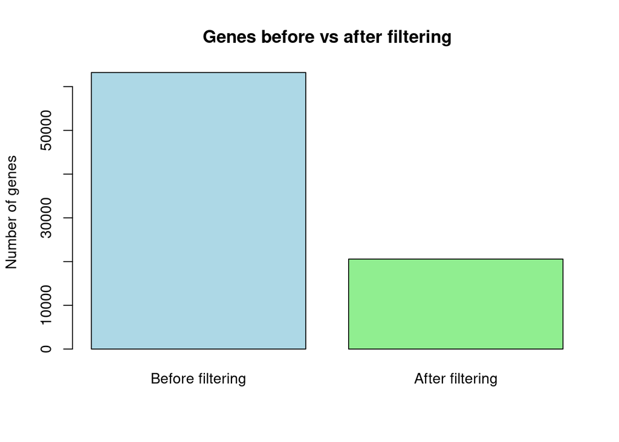

```r
# Create an R bar plot showing the change in gene counts before and after filtering
barplot(
  height = c(genes_before, genes_after),
  names.arg = c("Before filtering", "After filtering"),
  col = c("lightblue", "lightgreen"),
  ylab = "Number of genes",
  main = "Genes before vs after filtering",
)
```

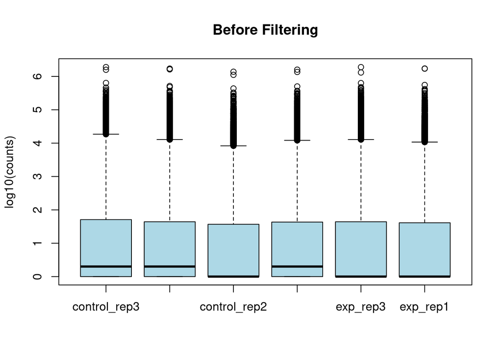

```r
# Create a box and whisker plot showing the distribution of gene counts between samples
boxplot(log10(cts + 1), main="Before Filtering", ylab="log10(counts)", col="lightblue")
```

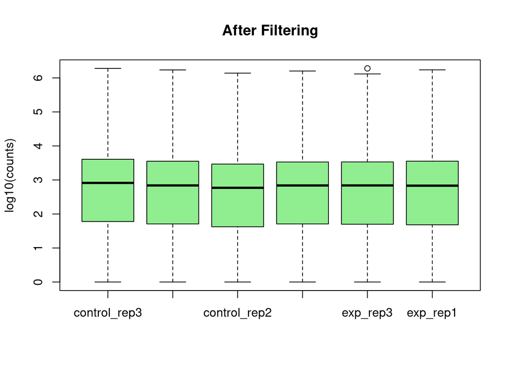

```r
boxplot(log10(filtered_counts + 1), main="After Filtering", ylab="log10(counts)", col="lightgreen")
```

### Generating colData for DESeq2

```r
# Manually create coldata file
coldata <- read.csv('coldata.csv',row.names=1)
coldata <- coldata[colnames(filtered_counts), , drop=FALSE]


# Checking all colnames match up between generated coldata and filtered counts
# before creating the DESeq2 object

#all(rownames(coldata) == colnames(filtered_counts))       # TRUE
```

### Constructing the DESeq2 Object (still ensemble ids)

```r
# Construct the DESeq2 object
dds <- DESeqDataSetFromMatrix(countData = filtered_counts,
                              colData = coldata,
                              design = ~ condition)
# Run the main DESeq2 pipeline
dds <- DESeq(dds)
# Extract the results comparing experimental vs. control samples
res <- results(dds, contrast=c("condition","experiment","control"))
#head(res)
```

### Configuring the DESeq2 Results (ordered by padj) in a tibble

```r
# Order all genes in the DESeq2 results table by their adjusted p-value (padj)
resOrdered <- res[order(res$padj),]
# Convert the ordered DESeq2 results into a tidy tibble, preserving gene names
deseq2_res <- as_tibble(resOrdered, rownames='gene')
```

### Mapping Gene Names to DESeq2 Results Tibble

```r
# Read in the gene ID-to-symbol mapping file generated from the GTF parse step
gene_ids <- read_tsv("gene_names.txt", col_names = c('gene', 'symbol'))
head(gene_ids)
```

```
## # A tibble: 6 × 2
##   gene              symbol
##   <chr>             <chr>
## 1 ENSG00000290825.1 DDX11L2
## 2 ENSG00000223972.6 DDX11L1
## 3 ENSG00000227232.6 WASH7P
## 4 ENSG00000278267.1 MIR6859-1
## 5 ENSG00000243485.5 MIR1302-2HG
## 6 ENSG00000284332.1 MIR1302-2
```

```r
# Join the DESeq2 results table with the gene annotation file to add gene symbols
deseq2_res <- deseq2_res %>% left_join(gene_ids) %>% relocate(symbol)
```

### Table of top 10 differentially expressed genes

```r
# Generate a visual table of the top 10 differentially expressed genes after ordering them by padj
top10 <- head(deseq2_res, 10)
top10
```

```
## # A tibble: 10 × 8
##    symbol         gene  baseMean log2FoldChange  lfcSE  stat    pvalue      padj
##    <chr>          <chr>    <dbl>          <dbl>  <dbl> <dbl>     <dbl>     <dbl>
##  1 RPS4Y1         ENSG…   10677.          -8.77 0.142  -61.7 0         0
##  2 ENSG000002895… ENSG…     732.           3.70 0.125   29.7 1.66e-193 1.58e-189
##  3 PNPO           ENSG…     605.          -4.16 0.141  -29.5 2.13e-191 1.35e-187
##  4 PCDHGA10       ENSG…     497.           4.48 0.200   22.4 6.36e-111 3.02e-107
##  5 YPEL3-DT       ENSG…     525.          -2.42 0.115  -21.0 1.03e- 97 3.92e- 94
##  6 LINC02506      ENSG…    1301.          -1.71 0.0986 -17.4 1.17e- 67 3.70e- 64
##  7 SLC2A14        ENSG…     634.           4.69 0.279   16.8 2.51e- 63 6.81e- 60
##  8 ENSG000002863… ENSG…     907.          -1.71 0.115  -14.9 2.41e- 50 5.71e- 47
##  9 ENSG000002894… ENSG…     384.          -2.13 0.145  -14.7 3.28e- 49 6.93e- 46
## 10 ENSG000002829… ENSG…     121.           3.76 0.264   14.2 6.86e- 46 1.30e- 42
```

```r
#res05 <- results(dds, alpha=0.05)

# Filters all the differentially expressed genes by the padj threshold (0.05)
# and generates a list of the gene symbols within that threshold
sig_genes_cts <- deseq2_res %>% filter(padj < 0.05)
res05_ordered <- deseq2_res %>%
  filter(padj<0.05) %>%
  select(symbol)
res05_ordered
```

```
## # A tibble: 1,254 × 1
##    symbol
##    <chr>
##  1 RPS4Y1
##  2 ENSG00000289575
##  3 PNPO
##  4 PCDHGA10
##  5 YPEL3-DT
##  6 LINC02506
##  7 SLC2A14
##  8 ENSG00000286339
##  9 ENSG00000289456
## 10 ENSG00000282914
## # ℹ 1,244 more rows
```

```r
# The number of significant genes remaining after filtering (this is just a list of genes)
genes_remaining <- nrow(res05_ordered)
genes_remaining # 1254 genes
```

```
## [1] 1254
```

```r
# Number of upregulated significant genes
up_sig <- sig_genes_cts %>% filter(log2FoldChange > 0) %>% nrow()
up_sig
```

```
## [1] 572
```

```r
# Number of downregulated significant genes
down_sig <- sig_genes_cts %>% filter(log2FoldChange < 0) %>% nrow()
down_sig
```

```
## [1] 682
```

```r
## Writing the list of significantly expressed genes (padj > 0.05) into a .txt file ('deseq2_sig_genes.txt')
sig_genes <- write.table(res05_ordered, file = "deseq2_sig_genes.txt", col.names = F, row.names = F, quote= F)
```

## Differential Expression Analysis

Differential expression analysis was performed on the filtered counts matrix using DESeq2; this program applies statistical methods based on a negative binomial distribution to normalize the sequence depth to reflect relative gene abundance, stabilizes the variance in biological variability among the samples and appliest hypothesis testing to identify genes exhibiting differential expression between conditions. DEseq2 outputs a list of significantly differentially expressed genes with associated quantitative measures, including log2 fold change, p-value, and adjusted p-value.

The next step was translating our quantitative DESeq2 data to qualitative results for functional enrichment analysis. To do this, we further refined the DESeq2 output by applying a p-adj threshold; this value essentially represents how likely the differential expression of a gene between our experimental and control groups could have happened by random chance, a low p-adj value indicates greater significance in differential expression. The p-adj threshold applied was p-adj < 0.05. The reasoning behind this choice had to do with the fact we were preparing for pathway enrichment using ENRICHr, while a stricter cutoff would reduce false positives, it was more important to get a better overall picture of what pathways and systems the genes correlated to. Since these enrichment analysis softwares evaluate genes collectively associated in pathways, rather than individually, I thought retaining a broader set of significant genes would create a more comprehensive set of biological processes and molecular systems.

ENRICHr analysis was done on the differentially expressed genes from DESeq2 satisfying the p-adj threshold (p-adj < 0.05), and a table of significant pathways was created to map the pathways our genes of interest map to. ENRICHr does not make distinctions between up and downregulation, just visualizes the overlap of our gene list to a pre-defined genesets. The enrichment analysis revealed a major correlation to extracellular matrix organization pathways, suggesting processes lined to changed in cell differentiation or stress response. Many pathways and enriched terms also correlated to neuronal systems, suggesting that neuron-specific transcription factors are being differentially expressed in this dataset. TP53 regulated transcription pathways were also identified, suggesting involvement in cell stress and apoptotic signaling. The ENRICHr findings indicate the identified DEGs are concentrated in pathways regulating cell structure, communication, and survival.

# Writing the Enrichr significant pathways results to a file

```r
# I exported the enrichr significant pathways to a file and reading them into a file
enrichr_results <- read.delim("enrichr_pathways.txt", header = TRUE, sep = "\t")

# Presenting the top pathways from Enrichr with their respective significance statistcs
# for a better visual and comparison
top_enrichr <- head(enrichr_results, 9)
top_enrichr
```

```
##                                                                                             Term
## 1                                                              Extracellular Matrix Organization
## 2 Regulation of IGF Transport and Uptake by Insulin-like Growth Factor Binding Proteins (IGFBPs)
## 3                                                                                Neuronal System
## 4                                                        Degradation of the Extracellular Matrix
## 5                                                     Post-translational Protein Phosphorylation
## 6               Regulation of Gene Expression in Endocrine-Committed (NEUROG3+) Progenitor Cells
## 7                                                             Integrin Cell Surface Interactions
## 8                                               TP53 Regulates Transcription of Cell Death Genes
## 9                                    TP53 Regulates Transcription of Death Receptors and Ligands
##   Overlap      P.value Adjusted.P.value Old.P.value Old.Adjusted.P.value
## 1  54/300 1.780855e-12     2.624980e-09           0                    0
## 2  28/124 2.262018e-09     1.667107e-06           0                    0
## 3  56/411 3.459885e-08     1.414681e-05           0                    0
## 4  28/140 3.839025e-08     1.414681e-05           0                    0
```

[output cut: 25 more lines]

## RNA-seq Quality Control Analysis

RNA-seq data can be sensitive to factors like library prep, sequencing depth, and other technical factors. RNA-seq quality control was done using generated plots to visually validate that our DEGS are in fact responding to experimental conditions. Variance-stabilizing transformation or vst() normalization was applied on the core DESeq2 data to mathematically transform counts so variance no longer depends on the mean. This essentially adjusts for the variable sequencing depth (85-120 million reads per library) observed earlier in FASTQC analysis. RNA-seq quality was evaluated using a principal component analysis (PCA) plot and a sample-sample heatmap: we were looking to confirm replicates from the same condition cluster together, and samples from different conditions are clearly separated.

##RNA-seq Quality Control Plots

```
## using ntop=500 top features by variance
```

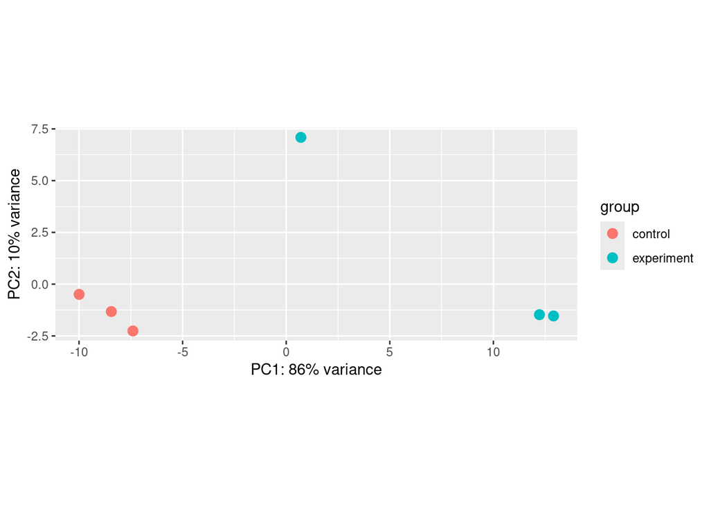

```r
library("pheatmap")
library("RColorBrewer")

# Apply variance-stabilizing transformation (VST) to the DESeq2 object
# blind = FALSE: tells DESeq2 to take the experimental design into account,
# so it won’t remove biological differences between conditions during transformation
vsd <- vst(dds, blind=FALSE)

#PCA Plot
plotPCA(vsd, intgroup=c("condition"))
```

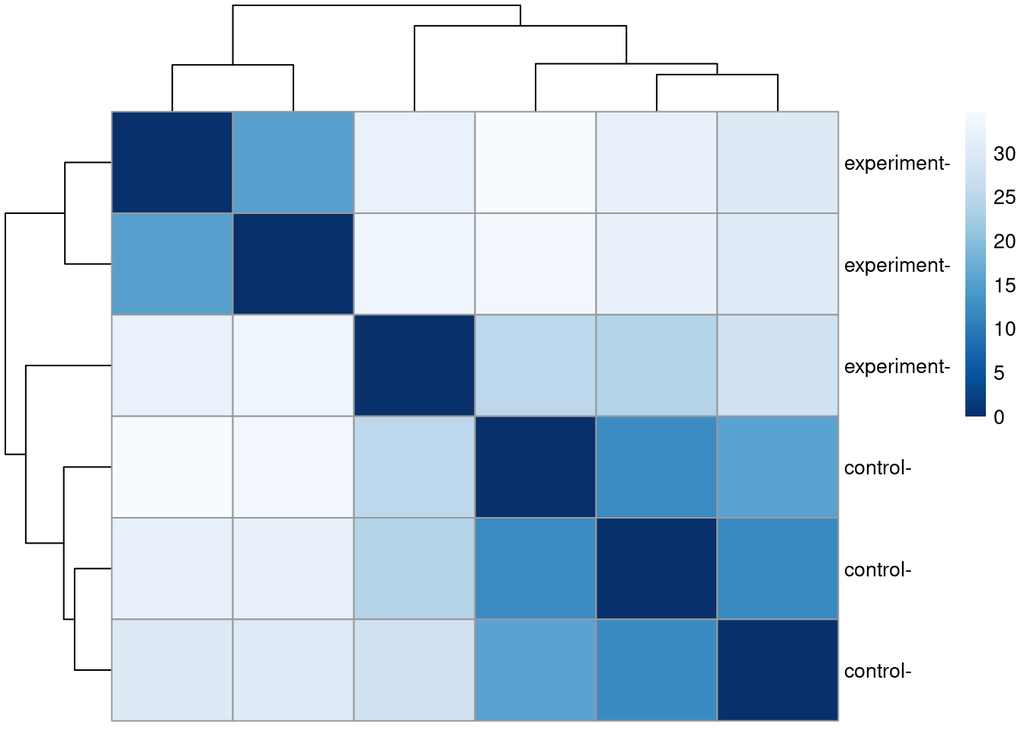

```r
#Heatmap
sampleDists <- dist(t(assay(vsd)))
sampleDistMatrix <- as.matrix(sampleDists)
rownames(sampleDistMatrix) <- paste(vsd$condition, vsd$type, sep="-")
colnames(sampleDistMatrix) <- NULL
colors <- colorRampPalette( rev(brewer.pal(9, "Blues")) )(255)
pheatmap(sampleDistMatrix,
         clustering_distance_rows=sampleDists,
         clustering_distance_cols=sampleDists,
         col=colors)
```

##Install fgsea

```r
BiocManager::install("fgsea")
```

##Load fgsea library

```r
library(fgsea)
```

##Generate an fgsea ranked list by log2FoldChange

```r
# # Prepare a ranked list of genes for FGSEA input, ranking by log2FoldChange
fgsea_ordered <- deseq2_res %>%
  drop_na() %>%
  distinct(symbol, .keep_all = TRUE) %>%
  arrange(desc(log2FoldChange))

# Create a named numeric vector for fgsea
fgsea_rnk_lst <- setNames(fgsea_ordered$log2FoldChange, fgsea_ordered$symbol)
fgsea_rnk_lst <- sort(fgsea_rnk_lst, decreasing = TRUE)
#head(fgsea_rnk_lst,10)
```

## Read in the gene symbols file (.gmt)

```r
# Load the pathway gene sets from the MSigDB C2: Canonical Pathways collection
fgsea_pathways <- fgsea::gmtPathways('c2.cp.v2025.1.Hs.symbols.gmt')
```

## Run fgsea (default parameters)

```r
# Run FGSEA with default parameters
fgsea_results <- fgsea(fgsea_pathways, fgsea_rnk_lst, minSize = 15, maxSize=500)
fgsea_results <- fgsea_results %>% as_tibble()
fgsea_results
```

```
## # A tibble: 2,350 × 8
##    pathway                    pval  padj log2err     ES    NES  size leadingEdge
##    <chr>                     <dbl> <dbl>   <dbl>  <dbl>  <dbl> <int> <list>
##  1 BIOCARTA_41BB_PATHWAY    0.989  1      0.0412 -0.200 -0.461    15 <chr [15]>
##  2 BIOCARTA_AGR_PATHWAY     0.317  0.799  0.0956 -0.405 -1.10     30 <chr [5]>
##  3 BIOCARTA_AKT_PATHWAY     0.753  1      0.0644  0.316  0.788    19 <chr [10]>
##  4 BIOCARTA_ALK_PATHWAY     0.0706 0.440  0.266   0.518  1.44     34 <chr [4]>
##  5 BIOCARTA_AMI_PATHWAY     0.0632 0.430  0.271   0.619  1.52     18 <chr [11]>
##  6 BIOCARTA_ARAP_PATHWAY    0.307  0.791  0.115   0.475  1.14     16 <chr [9]>
##  7 BIOCARTA_ARENRF2_PATHWAY 0.378  0.853  0.102   0.426  1.06     19 <chr [4]>
##  8 BIOCARTA_ARF_PATHWAY     0.0519 0.411  0.322   0.653  1.56     16 <chr [3]>
##  9 BIOCARTA_AT1R_PATHWAY    0.291  0.782  0.119   0.424  1.14     27 <chr [4]>
## 10 BIOCARTA_ATM_PATHWAY     0.964  1      0.0523  0.234  0.594    20 <chr [9]>
## # ℹ 2,340 more rows
```

## Exploring fgsea Results

```r
# Identify the top 5 significantly enriched UPREGULATED pathways (positive NES)
top_pos_nes <- fgsea_results %>%
  filter(padj < .25 & NES > 0) %>%
  slice_max(NES,n=5)

top_pos_nes
```

```
## # A tibble: 5 × 8
##   pathway                     pval    padj log2err    ES   NES  size leadingEdge
##   <chr>                      <dbl>   <dbl>   <dbl> <dbl> <dbl> <int> <list>
## 1 PID_P53_DOWNSTREAM_PATH… 2.74e-7 2.15e-4   0.675 0.619  2.19   134 <chr [55]>
## 2 REACTOME_ASSEMBLY_OF_CO… 7.80e-5 1.98e-2   0.538 0.703  2.12    52 <chr [22]>
## 3 PID_INTEGRIN1_PATHWAY    8.42e-5 1.98e-2   0.538 0.663  2.08    64 <chr [31]>
## 4 REACTOME_TP53_REGULATES… 1.57e-3 1.09e-1   0.455 0.709  2.06    42 <chr [21]>
## 5 PID_TAP63_PATHWAY        2.29e-4 3.59e-2   0.519 0.676  2.04    52 <chr [22]>
```

```r
# Identify the top 5 significantly enriched DOWNREGULATED pathways (negative NES)
top_neg_nes <- fgsea_results %>%
  filter(padj < .25 & NES < 0) %>%
  slice_min(NES,n=5)

top_neg_nes
```

```
## # A tibble: 5 × 8
##   pathway                    pval    padj log2err     ES   NES  size leadingEdge
##   <chr>                     <dbl>   <dbl>   <dbl>  <dbl> <dbl> <int> <list>
## 1 REACTOME_REGULATION_O… 1.66e- 4 2.89e-2   0.519 -0.721 -2.05    41 <chr [17]>
## 2 WP_SYNAPTIC_VESICLE_P… 1.57e- 4 2.89e-2   0.519 -0.677 -1.97    47 <chr [21]>
## 3 REACTOME_NEURONAL_SYS… 2.01e-10 4.72e-7   0.827 -0.536 -1.97   342 <chr [122]>
## 4 WP_CELL_LINEAGE_MAP_F… 3.42e- 5 1.01e-2   0.557 -0.613 -1.97   101 <chr [45]>
## 5 WP_DOPAMINERGIC_NEURO… 2.66e- 4 3.90e-2   0.498 -0.761 -1.96    24 <chr [15]>
```

## Creating a Figure Presenting FGSEA Results using Normalized Enrichment Score (NES)

[figure not shown]

```r
plot_data <- bind_rows(top_neg_nes, top_pos_nes) %>%
  mutate(direction = ifelse(NES > 0, "Up (NES>0)", "Down (NES<0)"))

plot_data %>%
  mutate(pathway = forcats::fct_reorder(pathway, NES)) %>%
  ggplot() +
  geom_bar(aes(x = pathway, y = NES, fill = direction), stat = "identity") +
  scale_fill_manual(values = c("Down (NES<0)" = "blue", "Up (NES>0)" = 'red'), name = "") +
  theme_minimal() +
  ggtitle("Top enriched pathways (padj < 0.25)") +
  ylab("Normalized Enrichment Score (NES)") +
  xlab("") +
  coord_flip(clip = "off")
```

## Replicate Figure 3C and 3F

The portion of interest in the study investigates how the loss of TYK2 influences transcriptional programs during different stages of pancreatic cell development. The given RNA-seq data correlates to stage 5 data in the publication, the endocrine progenitor stage: this is the stage where cells normally begin expressing transcription factors like NEUROG3 and NKX2-2 that initiate the formation of insulin-producing β-cells. This stage exhibited a rich opportunity for RNA-seq results because it was a critical developmental checkpoint where TYK2 knockout cells showed significant disruptions in gene expression. Using our results from DESeq2 analysis, we attempted to compare our results to those present in the publication.

The reproducibility of the publication results was further attempted in replicating their enrichment analysis results present in Figure 3F. The figure presents the most significantly enriched biological pathways based on the DEGs identified at Stage 5 between TYK2 knockout conditions. Our approach used Enrichr to identify the main pathways enriched among the differentially expressed genes and FGSEA to assess whether these pathways were up- or down-regulated. In the paper, a similar approach was done using ClusterProfiler v3.18.1 and the Reactome database, presenting an expected source of discrepancy. Though the resulting figures were not exactly the same, there were several sources of overlap. The upregulation of extracellular matrix (ECM) organization is a consistent result and leads to a conclusion in the paper that the TYK2-KO cells increase the expression of genes that structure the ECM, like collagen integrins, and matrix proteoglycans, to account for the increased proliferation levels and build the ECM. Another consistent enrichment analysis result was the downregulation of neuron development and systems. The paper uses this result to emphasize the idea that when pancreatic stem cells mature into endocrine cells (insulin-producing beta-cells), they activate some genes used by neurons. The reduced enrichment of these cells decreases expression of neurogenesis transcription factor genes like NEUROG3, NKX2-2, and INSM1, presenting an enriched pathway for neuronal development.

The overall enrichment results are closely aligned with the publication, especially for top-ranked enriched pathways. A few notable differences were observed, where our results identified additional stress-related pathways such as TP53 regulation of cell death genes, while the paper emphasized RTK signaling. These discrepancies were likely due to differences in enrichment tools and alignment databases and variations in variations in threshold selection.

### Recreating Figure 3C (Volcano Plot)

```r
BiocManager::install("EnhancedVolcano")
```

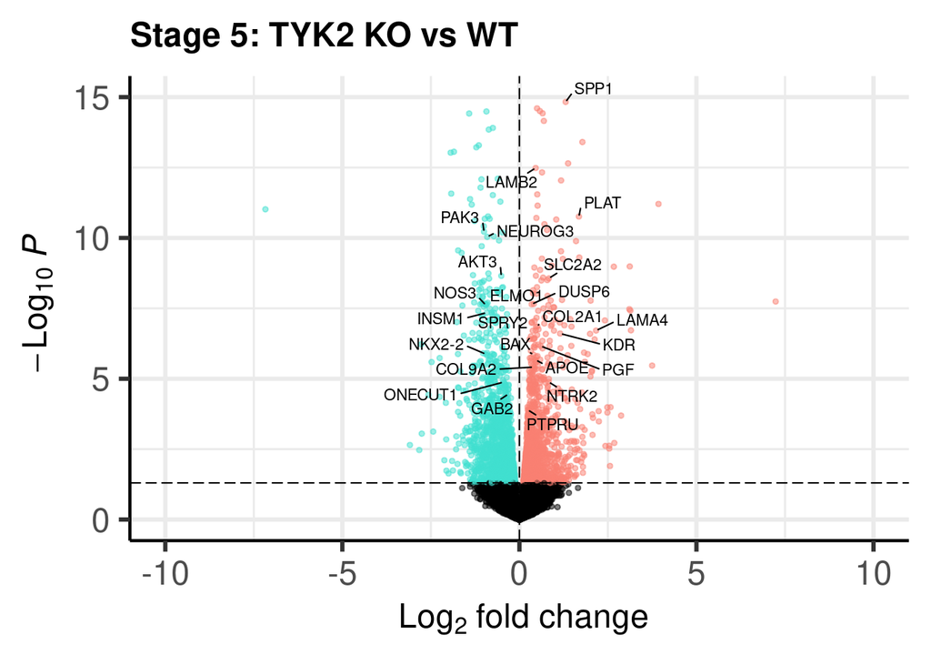

```r
library(ggplot2)
library(EnhancedVolcano)
#upregulated   <- res[res$pvalue < 0.05 & res$log2FoldChange >  0, ]
#downregulated <- res[res$pvalue < 0.05 & res$log2FoldChange <  0, ]
res_volc <- results(dds, contrast = c("condition", "experiment", "control"))
volcano_df <- as_tibble(res_volc, rownames = "gene") %>%
  left_join(gene_ids, by = "gene") %>%
  relocate(symbol) %>%
    mutate(
      direction = case_when(
        pvalue < 0.05 & log2FoldChange > 0  ~ "UP",  # now Up = KO, Down = WT
        pvalue < 0.05 & log2FoldChange < 0  ~ "DOWN",
        TRUE ~ "NS"
      )
    )
EnhancedVolcano(
  volcano_df,
  lab = volcano_df$symbol,
  x = "log2FoldChange",
  y = "pvalue",
  selectLab = c('KRAS','LAMB2','SPP1', 'DUSP6', 'SPRY2', 'AKT3', 'PLAT', 'SLC2A2', 'BAX','COL2A1', 'APOE', 'LAMA4', 'KDR', 'PGF', 'PTPRU', 'COL9A2', 'NTRK2', 'ELMO1', 'PAK3', 'INSM1', 'NEUROG3', 'GAB2', 'NOS3', 'ONECUT1', 'NKX2-2'),
  pointSize = 1.0,
  labSize = 3.0,
  pCutoff = 0.05,
  FCcutoff = 0,
  drawConnectors = TRUE,
  colConnectors = "black",
  widthConnectors = 0.4,
  lengthConnectors = unit(0.9, "npc"),
  arrowheads = FALSE,         # <-- key line: turns off triangular arrowheads
  boxedLabels = FALSE,        # plain text like the paper
  colCustom = c("NS"="black", "DOWN"="turquoise", "UP"="salmon")[volcano_df$direction],
  ylim = c(0, 15),             # <-- cap at ~18 to match the paper’s visual scale
  xlim = c(-10, 10),
  title = "Stage 5: TYK2 KO vs WT",
  legendPosition = "none",
  subtitle = NULL,
  caption = NULL
)
```

```r
volcano_df
```

```
## # A tibble: 20,579 × 9
##    symbol   gene  baseMean log2FoldChange lfcSE   stat  pvalue    padj direction
##    <chr>    <chr>    <dbl>          <dbl> <dbl>  <dbl>   <dbl>   <dbl> <chr>
##  1 WASH7P   ENSG…    180.          0.151  0.176  0.861 3.89e-1  0.847  NS
##  2 ENSG000… ENSG…     58.5         0.0494 0.256  0.193 8.47e-1  0.983  NS
##  3 ENSG000… ENSG…     36.2         0.0467 0.354  0.132 8.95e-1  0.989  NS
##  4 ENSG000… ENSG…     28.0         0.339  0.417  0.813 4.16e-1  0.863  NS
##  5 WASH9P   ENSG…    103.          0.197  0.201  0.981 3.27e-1  0.806  NS
##  6 ENSG000… ENSG…     28.0        -0.169  0.358 -0.471 6.38e-1  0.948  NS
##  7 ENSG000… ENSG…     38.3         0.330  0.383  0.863 3.88e-1  0.846  NS
##  8 ENSG000… ENSG…     13.0         0.239  0.593  0.404 6.86e-1 NA      NS
##  9 MTND1P23 ENSG…   1561.          0.366  0.138  2.65  8.03e-3  0.0959 UP
## 10 MTND2P28 ENSG…    969.          0.368  0.107  3.45  5.62e-4  0.0133 UP
## # ℹ 20,569 more rows
```

### Recreating Figure 3F (Reactome Enrichment Analysis)

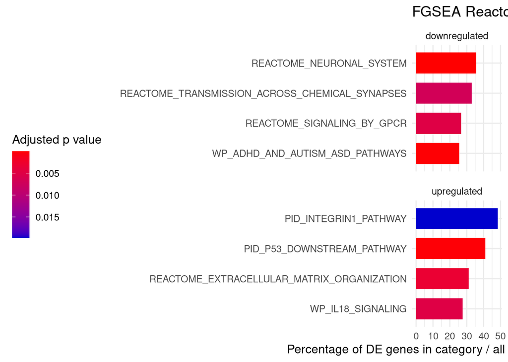

```r
library(dplyr)
library(ggplot2)
library(forcats)


fgsea_paths <- fgsea_results %>%
  filter(padj < 0.05, NES != 0) %>%        # only significant pathways
  mutate(direction = if_else(NES < 0, "downregulated", "upregulated"), percent_DE = 100 * lengths(leadingEdge) / size) %>%
  select(pathway, NES, padj, direction, percent_DE)

fgsea_plot_df <- write.table(fgsea_paths, "fgsea_pathways.txt", sep="\t", col.names=TRUE, row.names=FALSE, quote=FALSE)

plot_df <- fgsea_paths %>%
  group_by(direction) %>%
  arrange(padj) %>%   # smallest padj first
  slice_head(n = 4) %>%
  ungroup() %>%
  mutate(pathway = fct_reorder(pathway, percent_DE))

# Plot (Figure 3F style)
ggplot(plot_df, aes(x = percent_DE, y = pathway, fill = padj)) +
  geom_col(width = 0.7) +
  facet_wrap(~ direction, ncol = 1, scales = "free_y") +
  scale_fill_gradientn(
    colours = c("blue3","red"),
    trans = "reverse",
    name = "Adjusted p value"
  ) +
  labs(
    x = "Percentage of DE genes in category / all genes in category (%)",
    y = NULL,
    title = "FGSEA Reactome enrichment (ranked by adjusted p-value)"
  ) +
  theme_minimal(base_size = 12) +
  theme(panel.spacing.y = unit(10, "pt"),
        legend.position = "left")
```